# Multiple linear regression - `trees` dataset (solved)

```r
mod.q <- lm(Volume ~ Girth + I(Girth^2) + Height , data=trees)
summary(mod.q)
```

```
Call:
lm(formula = Volume ~ Girth + I(Girth^2) + Height, data = trees)

Residuals:
    Min      1Q  Median      3Q     Max
-4.2928 -1.6693 -0.1018  1.7851  4.3489

Coefficients:
            Estimate Std. Error t value Pr(>|t|)
(Intercept) -9.92041   10.07911  -0.984 0.333729
Girth       -2.88508    1.30985  -2.203 0.036343 *
I(Girth^2)   0.26862    0.04590   5.852 3.13e-06 ***
Height       0.37639    0.08823   4.266 0.000218 ***
---
Signif. codes:  0 ‘***’ 0.001 ‘**’ 0.01 ‘*’ 0.05 ‘.’ 0.1 ‘ ’ 1

Residual standard error: 2.625 on 27 degrees of freedom
Multiple R-squared:  0.9771,    Adjusted R-squared:  0.9745
F-statistic: 383.2 on 3 and 27 DF,  p-value: < 2.2e-16
```

```r
mod.int <- lm(Volume ~ Girth * Height, data=trees)
summary(mod.int)
```

```
Call:
lm(formula = Volume ~ Girth * Height, data = trees)

Residuals:
    Min      1Q  Median      3Q     Max
-6.5821 -1.0673  0.3026  1.5641  4.6649

Coefficients:
             Estimate Std. Error t value Pr(>|t|)
(Intercept)  69.39632   23.83575   2.911  0.00713 **
Girth        -5.85585    1.92134  -3.048  0.00511 **
Height       -1.29708    0.30984  -4.186  0.00027 ***
Girth:Height  0.13465    0.02438   5.524 7.48e-06 ***
---
Signif. codes:  0 ‘***’ 0.001 ‘**’ 0.01 ‘*’ 0.05 ‘.’ 0.1 ‘ ’ 1

Residual standard error: 2.709 on 27 degrees of freedom
Multiple R-squared:  0.9756,    Adjusted R-squared:  0.9728
F-statistic: 359.3 on 3 and 27 DF,  p-value: < 2.2e-16
```

i risultati evidenziano la significatività per i termini al quadrato (facciamo così per fittare la funzione parabola e cercare di spiegare meglio i dati spiegati), la relazione tra diametro e volume è perlopiù di questo tipo che non di semplice tipo lineare. Ora però ci viene un altro dubbio ecologico “diametro e altezza interagiscono insieme per determinare il volume dell’albero??” l’effetto dell’aumento in altezza potrebbe essere egato al diametro che stiamo considerando in quel momento. QUindi inseriamo adesso una qualche interazione tra le variabili x, con il simbolo moltiplicatore. QUindi il volume dell’albero testiamo che dipenda significativamente non solo sia da altezza e diametro ma anche dall’interazione tra le due. Per capire l’interazione tra le variabili guardare i grafici, nella tabella dei coefficienti talvolta viene negativo (il che non avrebbe senso per noi dire che l’altezza diminuisce all’aumentare del diametro, dipende da come R interpreta l’equazione).

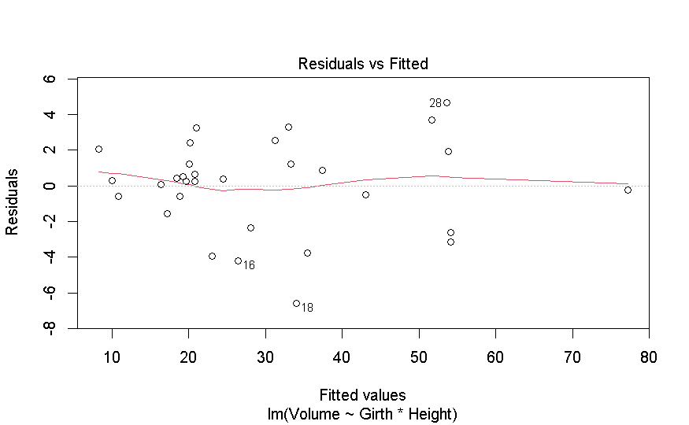

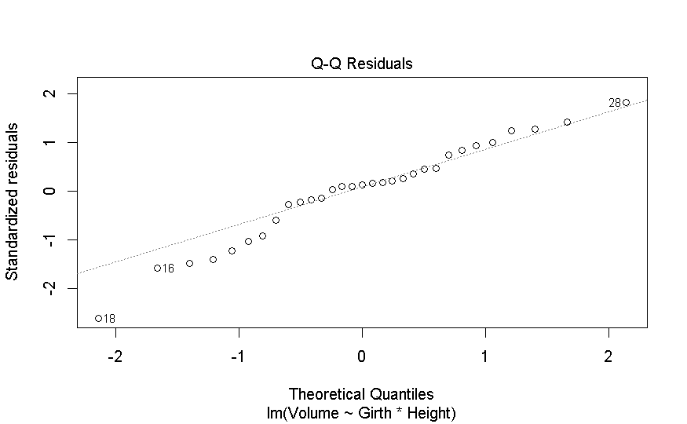

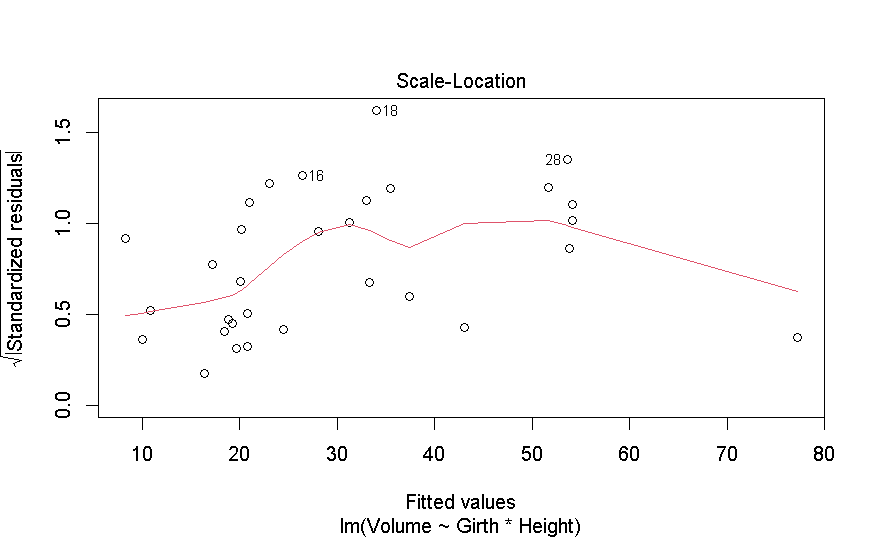

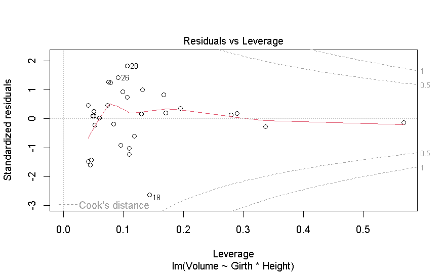

```r
mod <- lm(Volume ~ Girth * Height, data=trees)
plot(mod)
```

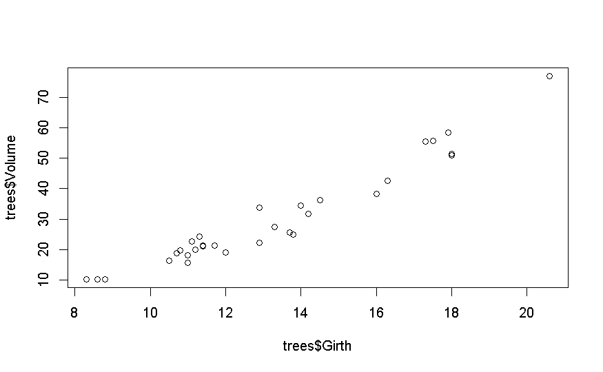

```r
plot(trees$Volume ~ trees$Girth)
```

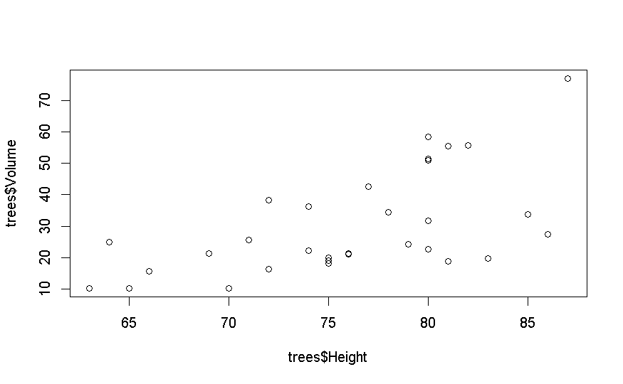

```r
plot(trees$Volume ~ trees$Height)
```

i risultati confermano questa nostra predilezione.Lo si vede anche dalla riga precedente Girth:Height 0.13465 0.02438 5.524 7.48e-06 *** Ma lo vogliamo testare graficamente.

```r
library(sjPlot)
# plot_model(mod)
```

```r
plot_model(mod, type = "eff", terms = "Girth")
```

```
Package `effects` required for this function to work.
```

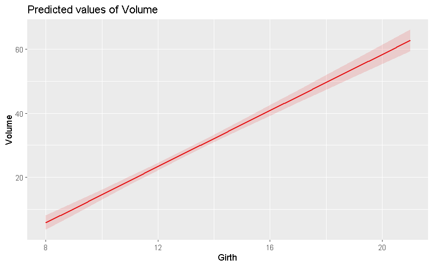

```r
y
```

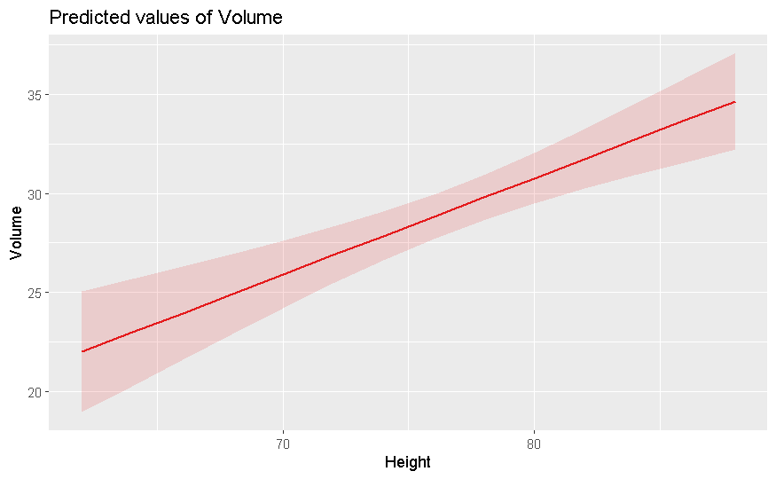

```r
plot_model(mod, type = "eff", terms = "Height")
```

andiamo adesso finalmente a plottare questo termine di interazione, e vogliamo vederne il grafico.

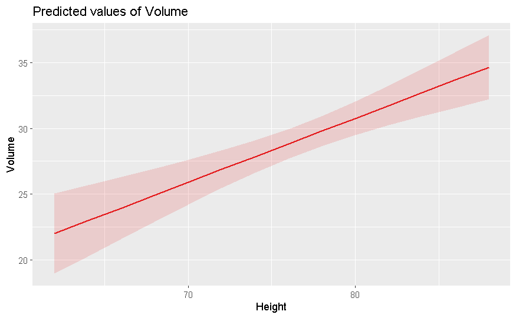

```r
plot_model(mod.int, type = "eff", terms = "Height")
```